# Documents and layout steps

Source: [`vignettes/v04-documents.Rmd`](https://github.com/rpahl/pubflow/blob/main/vignettes/v04-documents.Rmd)

Get started built a document with one *layout step*: a step that takes the outputs of other steps and arranges them with `pub_doc()` and `pub_section()`. This vignette is about what comes with real reports: inputs that fail, reports that show only some of the steps, a number of sections that depends on the data, a report over several pipelines, and how to test all of this. It builds on pipeflow’s vignettes [Pipeline views](https://cran.r-project.org/package=pipeflow/vignettes/v03b-pipeline-views.html), [Error handling](https://cran.r-project.org/package=pipeflow/vignettes/v05c-error-handling.html) and [Split, map and reduce](https://cran.r-project.org/package=pipeflow/vignettes/v05a-split-map-reduce.html).

```r
library(pipeflow)
library(pubflow)
library(ggplot2)
```

### The example

The pipeline of Get started again: `airquality` data, a linear model of the ozone concentration and a table, a figure and a text made from the model. The figure is made by a function defined outside the pipeline, which matters for the last section.

```r
coef_table <- function(model) {
    ci <- confint(model)
    coefs <- data.frame(
        term = rownames(ci),
        estimate = coef(model),
        lower = ci[, 1L],
        upper = ci[, 2L]
    )
    pub_table(
        coefs,
        caption = "Coefficients with 95% confidence limits",
        labels = c(
            term = "Term",
            estimate = "Estimate",
            lower = "Lower",
            upper = "Upper"
        ),
        digits = c(estimate = 3L, lower = 3L, upper = 3L)
    )
}

fit_figure <- function(model, data, xVar) {
    coefs <- coef(model)
    p <- ggplot(data, aes(.data[[xVar]], .data$Ozone)) +
        geom_point(na.rm = TRUE) +
        geom_abline(intercept = coefs[[1L]], slope = coefs[[2L]])
    pub_figure(p, caption = "Linear model fit", width = 6, height = 3.5)
}
```

```r
pip <- pip_new("ozone") |>
    pip_add("data", function(data = airquality) data) |>
    pip_add("prep", function(df = ~data) {
        df[, "Temp.Celsius"] <- (df[, "Temp"] - 32) * 5 / 9
        df
    }) |>
    pip_add("data_table", function(data = ~prep) {
        pub_table(
            head(data, 5L),
            caption = "The first rows of the data",
            digits = c(Temp.Celsius = 1L)
        )
    }) |>
    pip_add("fit", function(data = ~prep, xVar = "Temp.Celsius") {
        lm(paste("Ozone ~", xVar), data = data)
    }) |>
    pip_add("coef_table", coef_table, params = list(model = ~fit)) |>
    pip_add("plot", function(model = ~fit, data = ~prep, xVar = "Temp.Celsius") {
        fit_figure(model, data, xVar)
    }) |>
    pip_add("summary", function(model = ~fit) {
        pub_text(sprintf(
            "The model explains **%.0f%%** of the variance of the ozone concentration.",
            100 * summary(model)$r.squared
        ))
    })
```

`coef_table` is a function defined outside the pipeline and given to `pip_add()` as it is. A function can’t say `~fit` in its own signature, so `params` connects its argument `model` to the step `fit`. The step `plot` shows the other way: an inline function that only calls the outside one.

### Failures in a document

If a step fails, the steps that depend on it can’t run. A report should still show what is there, and say what is missing. That is the job of `~try(step)` in a layout step: instead of skipping the layout step, pipeflow hands it the *failure* of the input, and pubflow places it in the document as an error box.

```r
pip |>
    pip_add(
        "report",
        function(
            table = ~ try(data_table),
            coefs = ~ try(coef_table),
            plot = ~ try(plot),
            summary = ~ try(summary)
        ) {
            pub_doc(
                pub_section("Data", table),
                pub_section("Results", summary, coefs, plot),
                title = "Ozone in New York"
            )
        }
    )
```

Make `fit` fail by asking for a variable that the data doesn’t have. With `on_error = "continue"` the run goes on with the steps that don’t depend on `fit`:

```r
pip_set_params(pip, list(xVar = "Height"))
tryCatch(
    pip_run(pip, on_error = "continue", lgr = NULL),
    warning = function(w) cat(conditionMessage(w), "\n")
)
# Run of pipeline 'ozone' continued after 1 failed step:
#   'fit': object 'Height' not found
# Steps not run because an input failed: 'coef_table', 'plot', 'summary'
pip
# <pipeflow> ozone (8 steps)
# --------------------------
#          step                   params                            depends  state
# 1:       data                     data                                      done
# 2:       prep                       df                               data   done
# 3: data_table                     data                               prep   done
# 4:        fit                data,xVar                               prep failed
# 5: coef_table                    model                                fit    new
# 6:       plot          model,data,xVar                           fit,prep    new
# 7:    summary                    model                                fit    new
# 8:     report table,coefs,plot,summary data_table,coef_table,plot,summary   done
#                    out
# 1: <data.frame[153x6]>
# 2: <data.frame[153x7]>
# 3:     <huxtable[6x7]>
# 4: <error/simpleError>
# 5:              [NULL]
# 6:              [NULL]
# 7:              [NULL]
# 8:        <pub_doc[3]>
# --------------------------
# <continued> last run: 2026-11-16 18:32:43 (0.051 s)
# steps: 4 done, 1 failed, 3 new
```

The run warns (class `pipeflow_run_failed`), but the document is there. The steps `coef_table`, `plot` and `summary` didn’t run either, and each shows as an error box that names the cause:

```r
doc <- pip[["report", "out"]]
show(doc)
```

## Ozone in New York

### 1 Data

Table 1: The first rows of the data

| Ozone | Solar.R | Wind | Temp | Month | Day | Temp.Celsius |
| --- | --- | --- | --- | --- | --- | --- |
| 41 | 190 | 7.4000 | 67 | 5 | 1 | 19.4 |
| 36 | 118 | 8.0000 | 72 | 5 | 2 | 22.2 |
| 12 | 149 | 12.6000 | 74 | 5 | 3 | 23.3 |
| 18 | 313 | 11.5000 | 62 | 5 | 4 | 16.7 |
|  |  | 14.3000 | 56 | 5 | 5 | 13.3 |

### 2 Results

Step 'fit' failed

object 'Height' not found

Step 'summary' was not run.

Step 'fit' failed

object 'Height' not found

Step 'coef_table' was not run.

Step 'fit' failed

object 'Height' not found

Step 'plot' was not run.

A Shiny app can show such a document while the user fixes a param. The viewer (`pub_viewer_server()`) only renders the document that its `doc` reactive returns; it never runs a pipeline. The app does that: it calls `pip_run(on_error = "continue")` and passes the output of the layout step. A few rules go with it:

- Write `~try()` for **every** input of a layout step that may arrive failed. If you forget it for one input, pipeflow skips the layout step after a failure of that input, and there is no document at all.
- Computation steps choose `~try()` per argument, as in any pipeline. Normally they take a plain `~step`, so they never see a failure object.
- A report file is different: `pub_render()` refuses a document with error items, so that a report with a hole in it is never published by accident. (The report spec of `pub_report_spec()` can allow them.) Run the pipeline of a report with the default `on_error = "stop"`; the failed step then stops the run and there is no document.

```r
pub_render(doc, "docx")
# Error in `pub_render()`:
# ! Can't render a document with error items (failed steps) or missing parts:
# ✖ step 'fit' failed: object 'Height' not found
# ✖ step 'fit' failed: object 'Height' not found
# ✖ step 'fit' failed: object 'Height' not found
# ℹ Reports run the pipeline with `on_error = "stop"` and have all their parts; error items and missing parts are for the viewer.
```

Set the param back and the next run repairs the steps that failed:

```r
pip_set_params(pip, list(xVar = "Temp.Celsius"))
pip_run(pip, lgr = NULL)
pip
# <pipeflow> ozone (8 steps)
# --------------------------
#          step                   params                            depends state
# 1:       data                     data                                     done
# 2:       prep                       df                               data  done
# 3: data_table                     data                               prep  done
# 4:        fit                data,xVar                               prep  done
# 5: coef_table                    model                                fit  done
# 6:       plot          model,data,xVar                           fit,prep  done
# 7:    summary                    model                                fit  done
# 8:     report table,coefs,plot,summary data_table,coef_table,plot,summary  done
#                                            out
# 1:                         <data.frame[153x6]>
# 2:                         <data.frame[153x7]>
# 3:                             <huxtable[6x7]>
# 4:                                    <lm[13]>
# 5:                             <huxtable[3x4]>
# 6:                           <ggplot2::ggplot>
# 7: The model explains **49%** of the varian...
# 8:                                <pub_doc[3]>
# --------------------------
# <ready> last run: 2026-11-16 18:32:43 (0.061 s)
# steps: 8 done
```

### Select the steps of a report by tags

A pipeline often has more outputs than one report shows. Tag the steps with pipeflow’s tags, then let the tags decide which steps a layout step uses. `pub_layout_inputs()` returns the `~try(step)` references of a pipeline or of a view on it, for a layout step whose function takes `...`:

```r
tagged <- pip_reset(pip_clone(pip))
pip_tag(pip_view(tagged, step = c("summary", "coef_table")), c("short", "long"))
pip_tag(pip_view(tagged, step = c("data_table", "plot")), "long")
```

Each report is a layout step with its own tag. Add them last, because the steps are read when `pub_layout_inputs()` is called:

```r
tagged |>
    pip_add(
        "short",
        \(...) pub_doc(list(...), title = "Short report"),
        params = pub_layout_inputs(pip_view(tagged, tags = "short"))
    ) |>
    pip_add(
        "long",
        \(...) pub_doc(list(...), title = "Long report"),
        params = pub_layout_inputs(pip_view(tagged, tags = "long"))
    )
```

`list(...)` is a named list, which becomes one section per step, titled by the step’s name. `unname(list(...))` places the outputs one after the other, without sections. The reports share the steps, and a run of a view computes just what its report needs:

```r
pip_run(pip_view(tagged, step = "short"), lgr = NULL)
tagged
# <pipeflow> ozone (10 steps)
# ---------------------------
#           step                             params                            depends state
#  1:       data                               data                                     done
#  2:       prep                                 df                               data  done
#  3: data_table                               data                               prep   new
#  4:        fit                          data,xVar                               prep  done
#  5: coef_table                              model                                fit  done
#  6:       plot                    model,data,xVar                           fit,prep   new
#  7:    summary                              model                                fit  done
#  8:     report           table,coefs,plot,summary data_table,coef_table,plot,summary   new
#  9:      short                 coef_table,summary                 coef_table,summary  done
# 10:       long data_table,coef_table,plot,summary data_table,coef_table,plot,summary   new
#                                             out       tags
#  1:                         <data.frame[153x6]>
#  2:                         <data.frame[153x7]>
#  3:                                      [NULL]       long
#  4:                                    <lm[13]>
#  5:                             <huxtable[3x4]> short,long
#  6:                                      [NULL]       long
#  7: The model explains **49%** of the varian... short,long
#  8:                                      [NULL]
#  9:                                <pub_doc[3]>
# 10:                                      [NULL]
# ---------------------------
# <ready> last run: 2026-11-16 18:32:43 (0.023 s)
# steps: 6 done, 4 new
show(tagged[["short", "out"]])
```

## Short report

### 1 coef_table

Table 1: Coefficients with 95% confidence limits

| Term | Estimate | Lower | Upper |
| --- | --- | --- | --- |
| (Intercept) | -69.277 | -90.906 | -47.648 |
| Temp.Celsius | 4.372 | 3.540 | 5.203 |

### 2 summary

The model explains **49%** of the variance of the ozone concentration.

The steps `plot` and `data_table` are only needed by the long report and did not run.

Tags are one way to select; every view works, e.g. one on the steps that directly depend on `fit`: `pub_layout_inputs(pip_view(tagged, depends = "fit"))`. (A view that contains partitioned steps, see below, and other steps needs `exec = "reduce"` for the layout step; otherwise the layout step runs once per partition.)

#### One section per view

`pub_layout_sections()` makes a whole layout step with one section per view: the section is titled by the name of the view and shows the outputs of its steps in pipeline order. Here a tag selects the data section and the dependency on `fit` the model section:

```r
sectioned <- pip_reset(pip_clone(pip))
pip_tag(pip_view(sectioned, step = "data_table"), "data")
pip_add(
    sectioned,
    "by_section",
    pub_layout_sections(list(
        Data = pip_view(sectioned, tags = "data"),
        Model = pip_view(sectioned, depends = "fit")
    ))
)
pip_run(sectioned, lgr = NULL)
show(sectioned[["by_section", "out"]])
```

### 1 Data

Table 1: The first rows of the data

| Ozone | Solar.R | Wind | Temp | Month | Day | Temp.Celsius |
| --- | --- | --- | --- | --- | --- | --- |
| 41 | 190 | 7.4000 | 67 | 5 | 1 | 19.4 |
| 36 | 118 | 8.0000 | 72 | 5 | 2 | 22.2 |
| 12 | 149 | 12.6000 | 74 | 5 | 3 | 23.3 |
| 18 | 313 | 11.5000 | 62 | 5 | 4 | 16.7 |
|  |  | 14.3000 | 56 | 5 | 5 | 13.3 |

### 2 Model

Table 2: Coefficients with 95% confidence limits

| Term | Estimate | Lower | Upper |
| --- | --- | --- | --- |
| (Intercept) | -69.277 | -90.906 | -47.648 |
| Temp.Celsius | 4.372 | 3.540 | 5.203 |

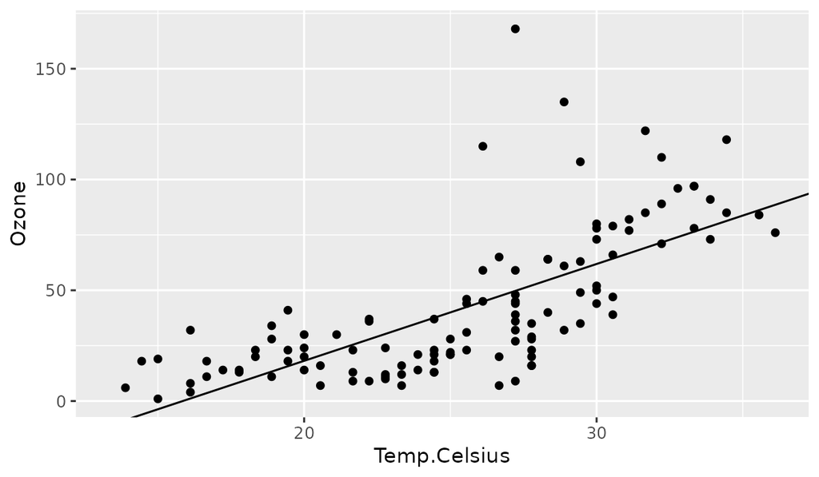

Figure 1: Linear model fit

The model explains **49%** of the variance of the ozone concentration.

A section whose outputs are all `NULL` is left out, so a step that a param switches off returns `NULL`.

### Layouts that change with the data

The structure of a document often depends on the data: one section per month, per site, per variable. Choose among three ways, from the simplest.

#### A step that returns a named list

The step `monthly` returns one table for every month in the data. A named list becomes one section per name when it is placed in a document, so the layout step needs no code for the months. If the data change, the sections change with them:

```r
monthly_tables <- function(data) {
    months <- split(data, data$Month)
    names(months) <- month.name[as.integer(names(months))]
    lapply(months, \(d) {
        pub_table(
            data.frame(
                Variable = c("Ozone (ppb)", "Temperature (°C)"),
                Mean = c(mean(d$Ozone, na.rm = TRUE), mean(d$Temp.Celsius))
            ),
            caption = sprintf("Means in %s", month.name[d$Month[[1L]]]),
            digits = c(Mean = 1L)
        )
    })
}

p2 <- pip_clone(pip) |>
    pip_add("monthly", monthly_tables, params = list(data = ~prep)) |>
    pip_add("by_month", function(tables = ~ try(monthly)) {
        pub_doc(tables, title = "Means by month")
    })

pip_run(p2, lgr = NULL)
```

```r
show(p2[["by_month", "out"]])
```

## Means by month

### 1 May

Table 1: Means in May

| Variable | Mean |
| --- | --- |
| Ozone (ppb) | 23.6 |
| Temperature (°C) | 18.6 |

### 2 June

Table 2: Means in June

| Variable | Mean |
| --- | --- |
| Ozone (ppb) | 29.4 |
| Temperature (°C) | 26.2 |

### 3 July

Table 3: Means in July

| Variable | Mean |
| --- | --- |
| Ozone (ppb) | 59.1 |
| Temperature (°C) | 28.8 |

### 4 August

Table 4: Means in August

| Variable | Mean |
| --- | --- |
| Ozone (ppb) | 60.0 |
| Temperature (°C) | 28.9 |

### 5 September

Table 5: Means in September

| Variable | Mean |
| --- | --- |
| Ozone (ppb) | 31.4 |
| Temperature (°C) | 24.9 |

This is the right tool when the content of a section is a few outputs made in one step. A step that returns a list is one step: if it fails, all sections fail together, and the pipeline can’t cache or re-run a single section.

#### Split steps: one partition per month

If each month needs its own chain of steps (a fit, a table and a figure per month), use pipeflow’s split steps: a step with `exec = "split"` returns a list, and every step downstream runs once per element, the *partitions*, until a step with `exec = "reduce"` takes them all. A layout step downstream of a split step runs once per partition and returns the section of that partition. The step doesn’t get the key of its partition, so the title comes from the data:

```r
ps <- pip_new("by-month") |>
    pip_add("data", function(data = airquality) {
        data$Temp.Celsius <- (data$Temp - 32) * 5 / 9
        data
    }) |>
    pip_add(
        "months",
        function(data = ~data) split(data, data$Month),
        exec = "split"
    ) |>
    pip_add("fit", function(data = ~months) lm(Ozone ~ Temp.Celsius, data = data)) |>
    pip_add("table", coef_table, params = list(model = ~fit)) |>
    pip_add("plot", function(model = ~fit, data = ~months) {
        fit_figure(model, data, "Temp.Celsius")
    }) |>
    pip_add("section", function(
        data = ~ try(months),
        table = ~ try(table),
        plot = ~ try(plot)
    ) {
        pub_section(month.name[data$Month[[1L]]], table, plot)
    })
```

A last step with `exec = "reduce"` gets the sections of all partitions as one partitioned output and builds the document. `unname()` places the sections one after the other; without it each partition becomes a sub-section titled by its key, around the section the step returned:

```r
ps <- pip_add(
    ps,
    "doc",
    function(sections = ~ try(section)) {
        pub_doc(
            pub_section("Months", unname(sections)),
            title = "Ozone by month"
        )
    },
    exec = "reduce"
)
pip_run(ps, lgr = NULL)
ps
# <pipeflow> by-month (7 steps)
# -----------------------------
#       step          params           depends state                 out   exec
# 1:    data            data                    done <data.frame[153x7]>   auto
# 2:  months            data              data  done           <list[5]>  split
# 3:     fit            data            months  done           <list[5]>   auto
# 4:   table           model               fit  done           <list[5]>   auto
# 5:    plot      model,data        fit,months  done           <list[5]>   auto
# 6: section data,table,plot months,table,plot  done           <list[5]>   auto
# 7:     doc        sections           section  done        <pub_doc[3]> reduce
# -----------------------------
# <ready> last run: 2026-11-16 18:32:44 (0.096 s)
# steps: 7 done
```

## Ozone by month

### 1 Months

#### 1.1 May

Table 1: Coefficients with 95% confidence limits

| Term | Estimate | Lower | Upper |
| --- | --- | --- | --- |
| (Intercept) | -41.845 | -83.979 | 0.288 |
| Temp.Celsius | 3.393 | 1.245 | 5.540 |

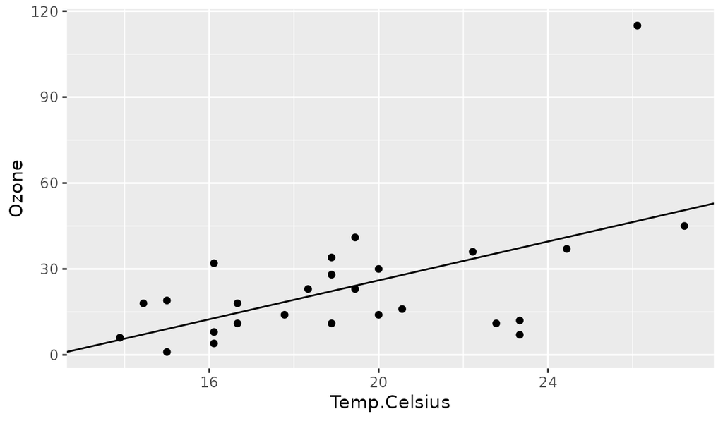

Figure 1: Linear model fit

#### 1.2 June

Table 2: Coefficients with 95% confidence limits

| Term | Estimate | Lower | Upper |
| --- | --- | --- | --- |
| (Intercept) | -42.313 | -114.599 | 29.973 |
| Temp.Celsius | 2.794 | 0.015 | 5.574 |

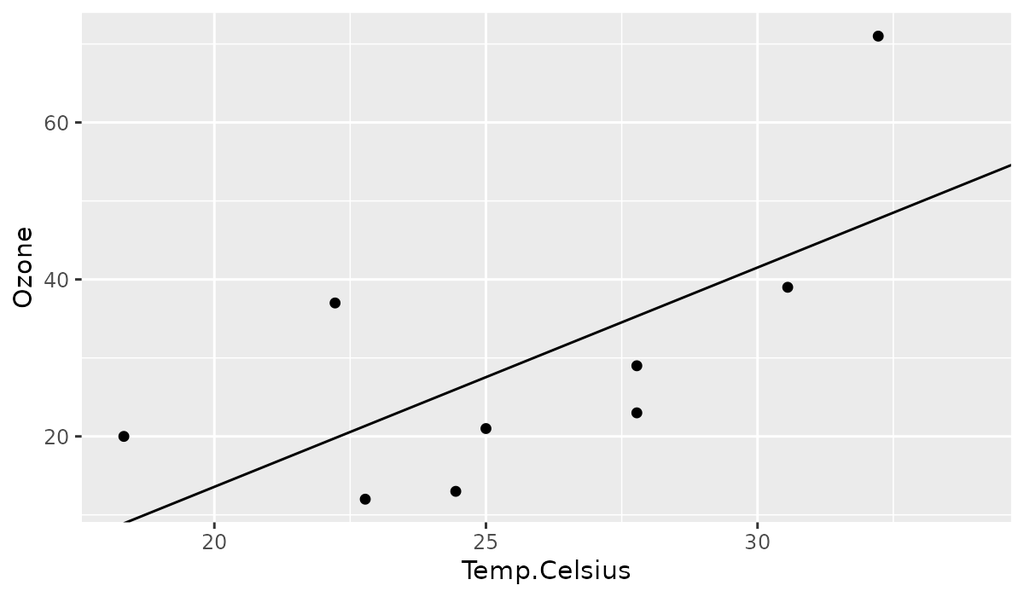

Figure 2: Linear model fit

#### 1.3 July

Table 3: Coefficients with 95% confidence limits

| Term | Estimate | Lower | Upper |
| --- | --- | --- | --- |
| (Intercept) | -208.109 | -316.153 | -100.065 |
| Temp.Celsius | 9.271 | 5.535 | 13.006 |

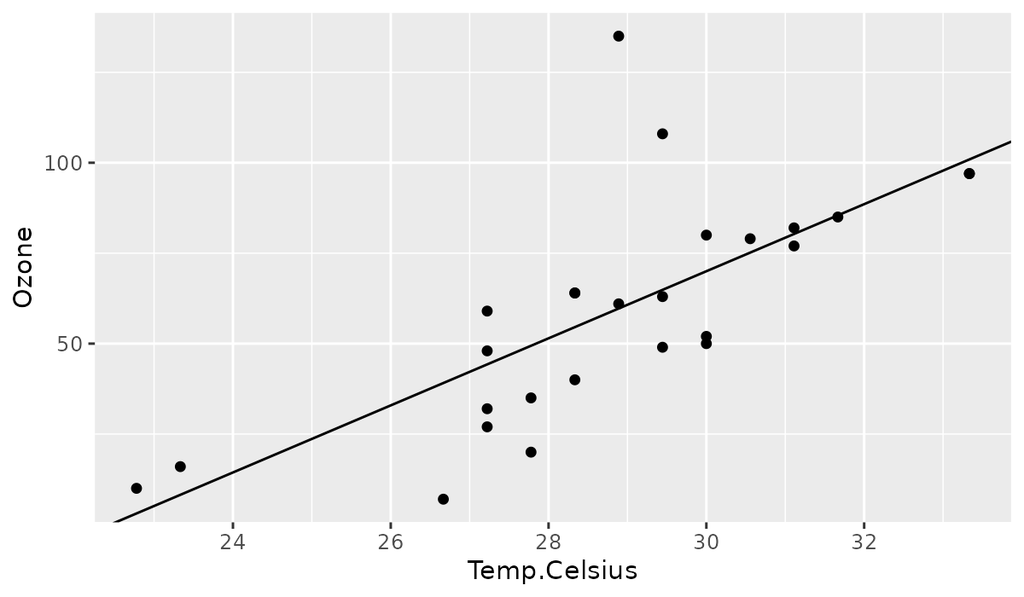

Figure 3: Linear model fit

#### 1.4 August

Table 4: Coefficients with 95% confidence limits

| Term | Estimate | Lower | Upper |
| --- | --- | --- | --- |
| (Intercept) | -124.972 | -230.246 | -19.698 |
| Temp.Celsius | 6.406 | 2.788 | 10.025 |

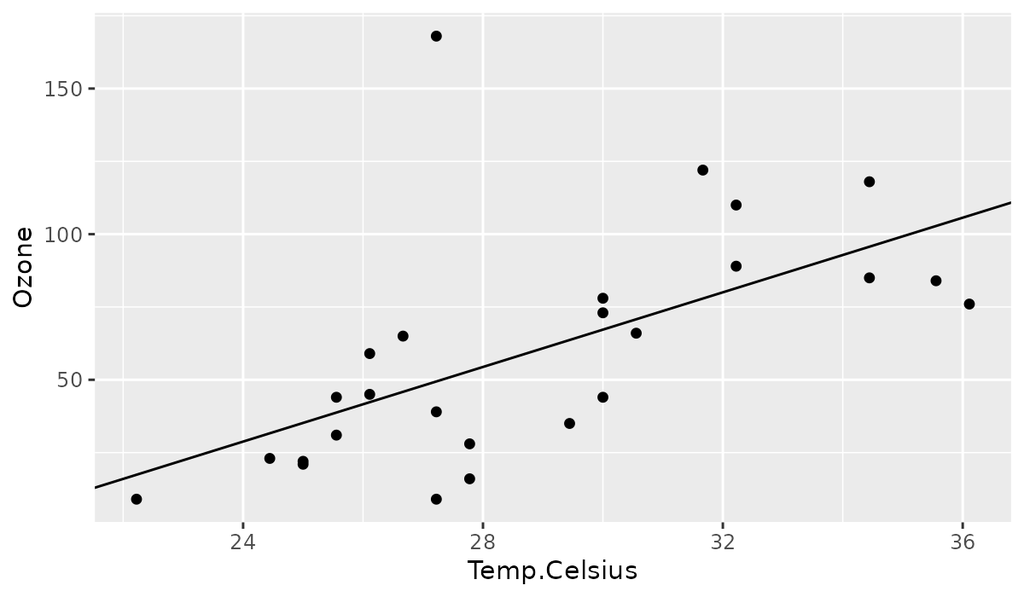

Figure 4: Linear model fit

#### 1.5 September

Table 5: Coefficients with 95% confidence limits

| Term | Estimate | Lower | Upper |
| --- | --- | --- | --- |
| (Intercept) | -74.110 | -102.806 | -45.415 |
| Temp.Celsius | 4.232 | 3.101 | 5.363 |

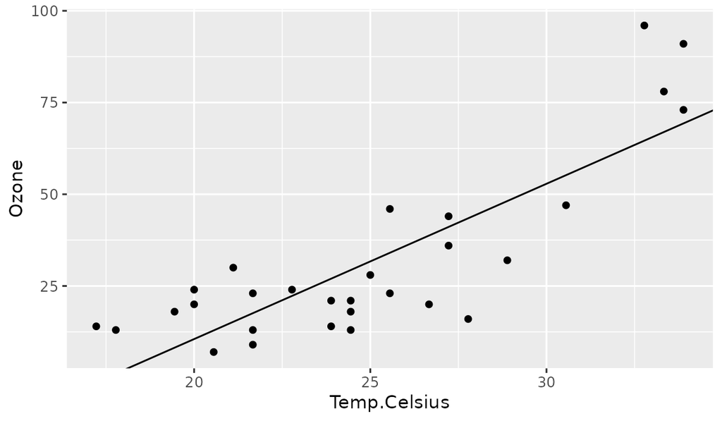

Figure 5: Linear model fit

Pipeflow’s split steps fail per partition. If the table of one month fails, its section shows an error box and the other months are complete. A failed month is also the only one that runs again in the next run, as long as the failed step’s params, exec mode and inputs are unchanged, no input ran again and the run is not forced. Note that a param change outdates a whole step: all its partitions run again, not only some.

Choose between the two like this: the named list is easiest if the content of a section is made in one step. Split steps pay off when the chain per month is long, when it can fail, or when its results are expensive to recompute after a failure. A third way, *nested pipelines* (a pipeline that is a step function through `as.function()`), is for groups that share one param set but are computed by a pipeline of their own; see pipeflow’s vignette [Nested pipelines](https://cran.r-project.org/package=pipeflow/vignettes/v05b-nested-pipeline.html).

#### What does not work: add steps while running

A step that adds steps to the pipeline in the course of a run (a step function that calls `pip_add(.self, ...)` for every month it finds) does not work for documents: the layout step can’t name a step that does not exist when it is added, because `pip_add()` rejects unknown `~step` references, and `pub_layout_inputs()` lists the steps present at that moment. Use a named list or a split step instead; both have as many outputs as there are months.

```r
pip_new("tmp") |>
    pip_add("report", function(table = ~ try(may_table)) pub_doc(table))
# Error:
# ! while adding step 'report' - cannot reference unknown steps: 'may_table'
```

### Documents across pipelines

Groups that have their own params, their own inputs or their own runs are better as *independent pipelines* made by one constructor than as one pipeline with partitions. A report can have one pipeline per month or per site, each with its own limits, its own parameter tab and its own run, possibly in a parallel worker. The report puts the parts together.

A constructor for a group’s pipeline. The layout step `content` makes the part of the report for this group. It takes a plain `~table`, so it is skipped when the table fails: the failure is handled where the parts are collected:

```r
month_pipeline <- function(name, month) {
    pip_new(name) |>
        pip_add("data", function(data = airquality, month = 5L) {
            data[data$Month == month, ]
        }) |>
        pip_add("mean", function(data = ~data, limit = 40) {
            m <- mean(data$Ozone, na.rm = TRUE)
            if (is.nan(m)) stop("no ozone values")
            c(mean = m, limit = limit)
        }) |>
        pip_add("table", function(res = ~mean) {
            pub_table(
                data.frame(
                    Quantity = c("Mean ozone", "Limit"),
                    Value = unname(res)
                ),
                caption = "Ozone (ppb)",
                digits = c(Value = 1L)
            )
        }) |>
        pip_add("content", function(table = ~table) list(table)) |>
        pip_set_params(list(month = month))
}

pips <- list(
    May = month_pipeline("May", 5L),
    June = month_pipeline("June", 6L),
    July = month_pipeline("July", 7L)
)
```

Each group is run on its own. Here a loop runs them; an app can run each in a parallel worker, which does the same and returns the pipeline:

```r
for (p in pips) {
    pip_run(p, on_error = "continue", lgr = NULL)
}
pips$May
# <pipeflow> May (4 steps)
# ------------------------
#       step     params depends state                out
# 1:    data data,month          done <data.frame[31x6]>
# 2:    mean data,limit    data  done  23.61538,40.00000
# 3:   table        res    mean  done    <huxtable[3x2]>
# 4: content      table   table  done          <list[1]>
# ------------------------
# <ready> last run: 2026-11-16 18:32:45 (0.012 s)
# steps: 4 done
```

#### Read the parts with `pub_out()`

The report takes the output of a group’s layout step with `pub_out()`. It differs from `p[["content", "out"]]` in one respect: it returns the output only if the step is `done`. After a failed run a step keeps its *earlier* output, so `p[[step, "out"]]` could silently put old results into a report.

```r
pub_out(pips$May, "content")
# [[1]]
#                                             Ozone (ppb)
#                                      ──────────────────────────
#                                        Quantity         Value
#                                      ──────────────────────────
#                                        Mean ozone        23.6
#                                        Limit             40.0
#                                      ──────────────────────────
#
# Column names: Quantity, Value
```

If the step is not done, `pub_out()` signals an error that names the pipeline and the failed steps. With `on_error = "item"` it returns an error item instead, which a document shows as an error box:

```r
pip_set_params(pips$June, list(month = 13L))
suppressWarnings(pip_run(pips$June, on_error = "continue", lgr = NULL))

pub_out(pips$June, "content")
# Error in `pub_out()`:
# ! The output of step 'content' of pipeline 'June' is not up to date (state "outdated").
# ✖ Step 'mean' failed: no ozone values
```

#### A report pipeline

A **report pipeline** puts the parts together. Its input step receives the parts as a param value, a layout step builds the document, and the rest of the report (cross-group tables, a summary of all groups) are ordinary steps of this pipeline. pipeflow skips a param value that is `identical()` to the old one, so parts that did not change don’t outdate anything:

```r
report <- pip_new("report") |>
    pip_add("parts", function(parts = list()) parts) |>
    pip_add("doc", function(parts = ~ try(parts)) {
        pub_doc(pub_section("Ozone by month", parts), title = "Ozone report")
    })
```

The parts are a named list, so each group becomes a section titled by its name. A group whose pipeline failed is shown as an error box in its section, and the other groups’ results are in the document:

```r
parts <- lapply(pips, pub_out, step = "content", on_error = "item")
pip_set_params(report, list(parts = parts))
pip_run(report, lgr = NULL)
show(report[["doc", "out"]])
```

## Ozone report

### 1 Ozone by month

#### 1.1 May

Table 1: Ozone (ppb)

| Quantity | Value |
| --- | --- |
| Mean ozone | 23.6 |
| Limit | 40.0 |

#### 1.2 June

Step 'mean' of pipeline 'June' failed

no ozone values

Step 'content' was not run.

#### 1.3 July

Table 2: Ozone (ppb)

| Quantity | Value |
| --- | --- |
| Mean ozone | 59.1 |
| Limit | 40.0 |

Repair the group and run the report pipeline again. The group’s own run re-runs only the steps that the param outdated, and the report pipeline gets the new part:

```r
pip_set_params(pips$June, list(month = 6L))
pip_run(pips$June, lgr = NULL)
parts <- lapply(pips, pub_out, step = "content", on_error = "item")
pip_set_params(report, list(parts = parts))
pip_run(report, lgr = NULL)
report
# <pipeflow> report (2 steps)
# ---------------------------
#     step params depends state          out
# 1: parts  parts          done    <list[3]>
# 2:   doc  parts   parts  done <pub_doc[3]>
# ---------------------------
# <ready> last run: 2026-11-16 18:32:45 (0.003 s)
# steps: 2 done
```

Three things to know when a worker runs the group’s pipeline:

- A pipeline survives `saveRDS()`, so a worker returns the *run pipeline* and the app keeps all states: the next run of that pipeline re-runs only outdated steps. The returned pipeline holds copies of its outputs, in which ggplots get new cache keys, so make figures in such steps with `pub_figure(render = TRUE)`: the step then returns the picture, not the plot.
- If the app only needs the part, the worker returns `pip_clone(p, out = "content")`: a copy without the outputs of the other steps, which is much smaller. `pub_out()` reads the part from it as from the pipeline, but the next run starts from scratch.
- Computations across groups (e.g. a table of all minima) are steps of the report pipeline. Give them the groups’ data as parts read with `pub_out()`, too.

### Test layout steps

A layout step is a function, and it is easy to test, with two kinds of tests. Both work on small data, so they run fast.

**The structure.** A layout step references the steps by their names, and `pip_add()` already rejects a name that does not exist (see above). Run the pipeline on a small data set and check the document:

```r
library(testthat)

test_that("the report has the sections and a figure", {
    pip <- report_pipeline() # your constructor
    pip_set_params(pip, list(data = airquality[1:30, ]))
    pip_run(pip, lgr = NULL)

    doc <- pip[["report", "out"]]
    expect_s3_class(doc, "pub_doc")
    expect_match(as.character(pub_html(doc)), "Coefficients with 95%")
})
```

**The failures.** A forgotten `~try()` is not an error: it makes the layout step skip, so the viewer shows no document after a failure. Make a step fail with a bad param, run on `on_error = "continue"`, and check that the document is still there and reports the failure:

```r
broken <- pip_clone(pip)
pip_set_params(broken, list(xVar = "Height"))
suppressWarnings(pip_run(broken, on_error = "continue", lgr = NULL))

doc <- broken[["report", "out"]]
class(doc)
# [1] "pub_doc"  "pub_node"
grepl("Step 'fit' failed", as.character(pub_html(doc)), fixed = TRUE)
# [1] TRUE
```

As a test:

```r
test_that("the report survives a failed fit", {
    pip <- report_pipeline()
    pip_set_params(pip, list(xVar = "Height"))
    suppressWarnings(pip_run(pip, on_error = "continue", lgr = NULL))

    doc <- pip[["report", "out"]]
    expect_s3_class(doc, "pub_doc")
    expect_match(as.character(pub_html(doc)), "Step 'fit' failed", fixed = TRUE)
})
```

For a report that must never be published with a hole in it, test the other direction: the run with the default `on_error = "stop"` stops, and `pub_render()` refuses a document with error items:

```r
test_that("a failed step stops the report run", {
    pip <- report_pipeline()
    pip_set_params(pip, list(xVar = "Height"))
    expect_error(pip_run(pip, lgr = NULL), class = "pipeflow_step_error")
})

test_that("pub_render() refuses error items", {
    pip <- report_pipeline()
    pip_set_params(pip, list(xVar = "Height"))
    suppressWarnings(pip_run(pip, on_error = "continue", lgr = NULL))

    expect_error(
        pub_render(pip[["report", "out"]], "docx"),
        class = "pubflow_render_error"
    )
})
```

### Steps that make figures

A ggplot keeps the environment in which it was made: the `aes()` mappings are quosures that point to the frame of the step, and that frame points to where the step function was defined. If that is a pipeline constructor, a figure carries the pipeline and everything the constructor holds, e.g. the data. As long as the figure stays in the pipeline, nobody notices. It costs as soon as it travels or lives without its pipeline: a document sent to a worker, saved with `saveRDS()` or kept by a viewer.

pubflow doesn’t check this at run time; the remedy is a habit:

- Write steps that make figures, fits or closures as **top-level functions** (in your package or script). Given to `pip_add()` directly (with `params` for the `~step` references, as for `coef_table`), neither the figure nor the stored step function encloses the constructor. An inline wrapper that only calls a top-level helper, as `plot` above, keeps the *figure* free of the constructor, but pipeflow stores the wrapper as given, so the saved pipeline still holds the constructor’s frame.
- Keep step functions out of a function that also holds large data. If a constructor takes the data as an argument, steps defined inside it enclose that data.
- Let an app test the serialized size of its real documents. The example makes the cost visible: a constructor holds 16 MB of data (`big`, used by another step) that the figure doesn’t show. The same figure is made by a function written inline in the constructor and by the top-level `small_plot()`:

```r
small_plot <- function(data) {
    pub_figure(
        ggplot(data, aes(.data$Temp, .data$Ozone)) + geom_point(na.rm = TRUE),
        caption = "Ozone by temperature"
    )
}

make_pipeline <- function(big) {
    pip_new("sizes") |>
        pip_add("data", function(data = airquality) data) |>
        pip_add("other", function(x = big) mean(x)) |>
        pip_add("inline", function(data = ~data) {
            pub_figure(
                ggplot(data, aes(.data$Temp, .data$Ozone)) +
                    geom_point(na.rm = TRUE),
                caption = "Ozone by temperature"
            )
        }) |>
        pip_add("top_level", small_plot, params = list(data = ~data))
}

sizes <- make_pipeline(big = rnorm(2e6))
pip_run(sizes, lgr = NULL)
figures <- sizes[["out"]][c("inline", "top_level")]
round(vapply(figures, \(f) length(serialize(f, NULL)) / 1e6, numeric(1L)), 2) # MB
#    inline top_level
#     16.78      0.78
```